# 607 Project 3 : East West Crime Compare

Kumudini Bhave, Shyam BV, Mark Halpin, Upal Chowdhury

October 18, 2016

# **Crime DataSet Study : Crime Data Study , a comparison between East Coast city , New York City (NYC) and West Coast city San Francisco (SFO) and MidWest city Chicago (CHI)**

## Summary

This is an R Markdown document for providing documentation for performing **Data Exploration And Analysis Of the Crime DataSet of publicly available crime data for New York City and San Francisco and Chicago**

## R Code :

### Forming MYSQL DB Connection to Crime Schema

Database MYSQL set up in cloud. Connection and access to database can be obtained as follows through amazon web services. @schema crimedb

The connection object ‘conn’ will further be used for querying and manipulating database tables.

## San Francisco (SFO) DataSet Study

### Fetching San Francisco (SFO) DataSet from JSON file

This JSON has two parts. First section has the meta data and second section will have the actual data

### Analyze by timeframe and top crimes

## New York City (NYC) DataSet Study

### Loading New York City (NYC) DataSet

Loading the crime data. Reading data file in XML format, from the GitHub location with Header as True

### Data Manipulation New York City (NYC) DataSet

Selecting columns from the NYC dataset for study

### Populating Crimedb database CrimeData table with New York City (NYC) Crime Data

The data loaded in to data frame which is manipulated is now selected for database posting into **crimedata** table

### Tidying NYC Crime data to make it plot ready

#### Group by **Bourough** and **Offense**

Performing group by operations on the dataset to grou by borough and within borough, group by offense.

#### Group by **Week#** and **Offense**

Performing group by operations on the dataset to grou by Week# and within Week#, group by Offense.

#### Group by **Hour#** and **Offense**

Performing group by operations on the dataset to grou by Hour# and within Hour#, group by Offense.

### NYC DataSet Plots

#### Hour vs Offense

**Findings** :

Assaults also happening during early hours , perhaps denoting early day travelers.

Thefts in general, any kind of larceny occurs more during day time. similarly robbery is being observed to be happening in NYC area prmarily in late evenings.

Heinous crimes of Murder /Sexual assualts are being seen occurrirng in day time however it can be a risk anytime of day.

#### Offense vs Borough

Heinous crime of murder / rape are much lesser compared to Grand Larceny which is high in all boroughs in comaprison to other offenses.

Brooklyn has the highest burglary as well as robbery rate among all the boroughs.

## Chicago (CHI) DataSet Study

### Loading Chicago (CHI) DataSet into R from an external source:

```r
chicago <- read.csv("https://raw.githubusercontent.com/bvshyam/Project3_cuny_607/master/Data/chicago_dec2015.csv", header=TRUE, sep=",", stringsAsFactors = FALSE,na.strings = c("",NA,"n/a","N/A","NA"))
```

### Clean the data!

As the data is in a format of “M/D/Y H:M:S”, we need to break that down and separate the data so we can get more fine grained analysis with it. To do so, we use the lubridate and stringr library. String allows us to use regular expressions to filter data, and lubridate provides easy to use, nicely abstracted functions to transform the data into time formats. As the timestamp is in the AM/PM format, we have to convert everything to twenty four hour time so that you as the analyst can tell the difference. Otherwise, the data will just all show a 12 hr format with no distinction. Once this occurs, we can perform calculations on the data. We are also going to extract out the hours, minutes, and seconds of the crime.

```r
crimeDates <- as.Date(chicago$Date, "%m/%d/%Y")
twentyFourHourTime <- as.POSIXct(chicago$Date, format = "%m/%d/%Y %I:%M:%S %p")
chicagoTimes <- unlist(str_extract_all(twentyFourHourTime, pattern="\\d{1,2}\\:\\d{1,2}\\:\\d{1,2}"))
partOfDay <- unlist(str_extract_all(chicago$Date, pattern="[[:alpha:]]{2}"))
dayOfWeek <- wday(crimeDates, label = TRUE)
crimeMonth <- month(crimeDates, label = TRUE)
crimeTimeStamp <- hms(chicagoTimes)
crimeHr <- hour(crimeTimeStamp)
crimeMin <- minute(crimeTimeStamp)
crimeSec <- second(crimeTimeStamp)
```

Once the data has been cleaned, we need to put it into a new data frame for further analysis.

```r
cleanedData <- data.frame(
crimeType = chicago$Primary.Type,
wasArrestMade = chicago$Arrest,
district = chicago$District,
location = chicago$Location.Description,
crimeDates,
dayOfWeek,
crimeMonth,
crimeHr,
crimeMin,
crimeSec,
latitude = chicago$Latitude,
longitude =chicago$Longitude
)
```

For the purpose of adding the data into the shared database, I need to add the time and crime id.

```r
cleanedData$offenseid <- chicago$ID
cleanedData$offenselocaltime <- chicagoTimes
```

### Create a dataframe in the format expected in the database

```r
dataForDB <- data.frame (
cityCode = "CHI",
offenseid = cleanedData$offenseid,
offense = cleanedData$crimeType,
offenselocaldate =cleanedData$crimeDates,
offenselocaltime = cleanedData$offenselocaltime,
offensehour= cleanedData$crimeHr,
offensemonth= cleanedData$crimeMonth,
offensearea = cleanedData$location
)

dataForDB$dayofweek <- weekdays(as.Date(crimeDates))

dataForDB <- dataForDB[c(1,2,3,4,5,9,6,7,8)]
```

Create the connection to the database, and insert the data

```r
conn <- dbConnect(MySQL(),
                 user = 'mygroup',
                 password = 'mygroup#01',
                 host = 'mygroup.c5rotlbjbl71.us-east-1.rds.amazonaws.com',
                 dbname = 'crimedb')

dbWriteTable(conn, value = dataForDB, name = "crimedata", row.names=F, append = TRUE )
```

```
## [1] TRUE
```

### Analysis

What we are most interested in for the analysis is finding how the primary crime types compare in terms of arrest rates. First, we need to group the data by the primary type and arrest data (true or false). We can then count how many of each occurred.

```r
table(cleanedData$crimeType, cleanedData$wasArrestMade )
```

```
##
##                                     false true
##   ARSON                                27    1
##   ASSAULT                             967  236
##   BATTERY                            2815  772
##   BURGLARY                           1261   66
##   CONCEALED CARRY LICENSE VIOLATION     0    2
##   CRIM SEXUAL ASSAULT                  88    5
##   CRIMINAL DAMAGE                    2286  126
##   CRIMINAL TRESPASS                   160  273
##   DECEPTIVE PRACTICE                 1173   54
##   GAMBLING                              0    2
##   HOMICIDE                             26    7
##   INTERFERENCE WITH PUBLIC OFFICER      3   64
##   INTIMIDATION                          9    2
##   KIDNAPPING                           18    1
##   LIQUOR LAW VIOLATION                  0   10
##   MOTOR VEHICLE THEFT                 832   65
##   NARCOTICS                             0 1264
##   NON-CRIMINAL                          2    0
##   NON - CRIMINAL                        1    0
##   OBSCENITY                             2    1
##   OFFENSE INVOLVING CHILDREN          148   23
##   OTHER OFFENSE                      1004  240
##   PROSTITUTION                          0   65
##   PUBLIC INDECENCY                      0    2
##   PUBLIC PEACE VIOLATION               47   93
##   ROBBERY                             928   70
##   SEX OFFENSE                          47   14
##   STALKING                              9    0
##   THEFT                              4345  548
##   WEAPONS VIOLATION                    37  128
```

Here we see that the narcotics crime type has the highest number of arrests, while the theft crime type has the highest number of non-arrests.

We can then find out where one is most likely to get arrested by grouping the data together based on a crime type, arrest boolean, and location. Once this is done, we can compare the data of arrests and non arrests. The following barplot shows the arrests that did occur as “true”, and arrests that did not occur as “false”

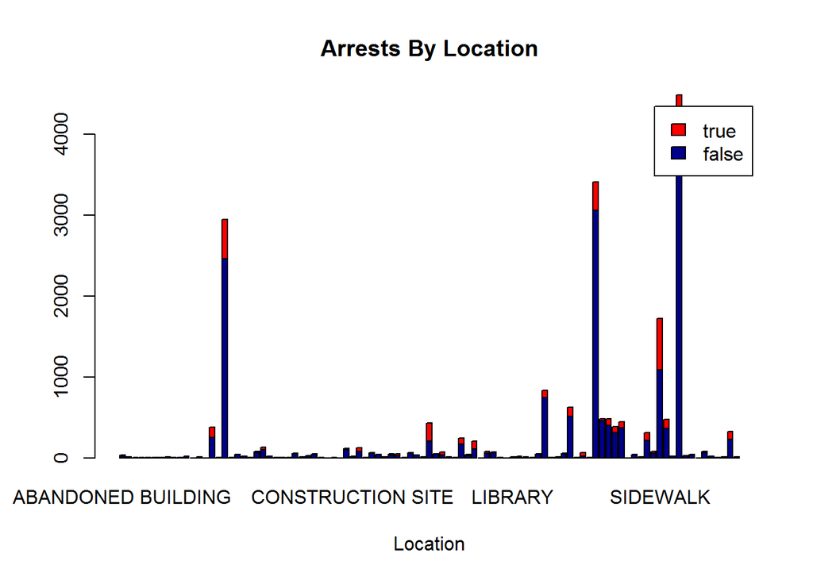

```r
arrestByLocation <- table(cleanedData$wasArrestMade, cleanedData$location )
barplot(arrestByLocation, main="Arrests By Location", xlab="Location", col=c("darkblue","red"), legend = rownames(arrestByLocation))
```

The same data can be viewed in a neater format via the group by command

```r
groupedCrimesByLocation <- cleanedData %>% group_by(crimeType, wasArrestMade, location) %>% summarise(Total=n())

arrestOnly <- filter(groupedCrimesByLocation, wasArrestMade %in% "true")

arrestOnly
```

```
## Source: local data frame [407 x 4]
## Groups: crimeType, wasArrestMade [27]
##
##    crimeType wasArrestMade                                    location
##       <fctr>        <fctr>                                      <fctr>
## 1      ARSON          true                                   APARTMENT
## 2    ASSAULT          true AIRPORT BUILDING NON-TERMINAL - SECURE AREA
## 3    ASSAULT          true                                       ALLEY
## 4    ASSAULT          true                                   APARTMENT
## 5    ASSAULT          true                                        BANK
## 6    ASSAULT          true                               BAR OR TAVERN
## 7    ASSAULT          true                                    CAR WASH
## 8    ASSAULT          true                               CHA APARTMENT
## 9    ASSAULT          true              CHA HALLWAY/STAIRWELL/ELEVATOR
## 10   ASSAULT          true                     CHA PARKING LOT/GROUNDS
## # ... with 397 more rows, and 1 more variables: Total <int>
```

```r
arrestOnly[which.max(arrestOnly$Total),]
```

```
## Source: local data frame [1 x 4]
## Groups: crimeType, wasArrestMade [1]
##
##   crimeType wasArrestMade location Total
##      <fctr>        <fctr>   <fctr> <int>
## 1 NARCOTICS          true   STREET   424
```

```r
noArrest <- filter(groupedCrimesByLocation, wasArrestMade %in% "false")

noArrest
```

```
## Source: local data frame [606 x 4]
## Groups: crimeType, wasArrestMade [24]
##
##    crimeType wasArrestMade                          location Total
##       <fctr>        <fctr>                            <fctr> <int>
## 1      ARSON         false                             ALLEY     1
## 2      ARSON         false                         APARTMENT     3
## 3      ARSON         false CHURCH/SYNAGOGUE/PLACE OF WORSHIP     1
## 4      ARSON         false                 CONVENIENCE STORE     1
## 5      ARSON         false            DRIVEWAY - RESIDENTIAL     1
## 6      ARSON         false                       GAS STATION     1
## 7      ARSON         false                GROCERY FOOD STORE     1
## 8      ARSON         false                             OTHER     1
## 9      ARSON         false    PARKING LOT/GARAGE(NON.RESID.)     3
## 10     ARSON         false                         RESIDENCE     5
## # ... with 596 more rows
```

```r
noArrest[which.max(noArrest$Total),]
```

```
## Source: local data frame [1 x 4]
## Groups: crimeType, wasArrestMade [1]
##
##   crimeType wasArrestMade location Total
##      <fctr>        <fctr>   <fctr> <int>
## 1     THEFT         false   STREET  1205
```

As the data shows, more people are likely to be arrested for a narcotics charge on the street. It also shows that one has a greater chance of not being arrested for theft on the street as well.

Speaking of arrests, one interesting observation would be to find what day of the week someone is likely to be arrested.

```r
table(cleanedData$wasArrestMade, cleanedData$dayOfWeek )
```

```
##
##          Sun  Mon Tues  Wed Thurs  Fri  Sat
##   false 2083 2095 2775 2749  2277 2072 2184
##   true   566  490  773  706   523  509  567
```

Based on this information, Tuesday is the day when most people are arrested for the sample.

```r
mean(twentyFourHourTime)
```

```
## [1] "2015-12-15 13:59:45 EST"
```

## Mapping Crime Data For US Cities

### Mapping for East Coast City New York city (NYC)

### Mapping for MidWest City Chicago

### Mapping for West Coast City San Francisco (SFO)

## Crime Compare for Major US Cities, West Coast SFO, East Coast NYC, Mid-West Chicago

### Loading Captured Crime Data From All Cities

Loading crime data captured for different US cities, EastCoast NYC, WestCoast SFO and MidWest Chicago.

### Data Manipulation And Plots For Crime Compare Across Cities

Grouping data retrieved from database with group by city and within city, group by offense

### Plot Offense Vs Cities

Safest City seems to be New York City area as comapred to San Francisco and Chicago.

### Close database connection

## Motivation

The project motivation has been to successfully demonstrate a team work, soft skills which also form the foundation of a good Data Scientist. And with collaboration help study crime data and come up with insights.

## Efforts

We collaborated together as a team of Kumudini Bhave, Shyam BV, Mark Halpin since Oct 16 to be joined in by Upal Chowdhury. Our team demonstrated great team work with work distribution, accommodation and tolerance and healthy collaboration .

Shyam, Mark did great work over finding interesting datasets and worked /analyzed on SFO , Chicago crime datasets. Kumudini contributed to working and analyzing on NYC crime data, doing across cities plot and integrating the individual Rmds. Upal was very instrumental in setting the much required database on cloud and helping us be all in sync. Having a database on cloud made it greatly possible to have all data in one place and reinforced the strength of the project. Upal also did some interesting mappings of the three cities SFO, NYC and Chicago crime datasets.And prepared the ER diagram and Workflow diagram

## Difficulties Faced

We did have initial dilemma as we started off with multiyear crime data but over period realised that only a months data could be handled by the environment. It consumed some time for this realization.

We also had issues with integration of Rmd files as JSON data loading would time out.

## Findings

With our team work, we were succesfully able to study crime across the major cities on East Coast, West Coast and Mid-West of USA . The Plots an our findings are captured in the main Rmd file.

## Which are the most valued data science skills?

The most valued data science skills : Our team worked together and could demonstrate the essential and most valued data science skills. We found the apt dataset for our project that engaged our curiousity to find about crime in different cities. We worked through unstructured /structured data We scraped data in different formats of XML, CSV, JSON We worked in SQL and posted to relational databases We used R for Coding We worked on large datasets and performed data mining. Lastly and most importantly, we are a team globally dispersed across timezones , we worked round the clock to deliver the united effort.